# Peer Review Assignment: ETL and EDA with Python and SQL

## Submitted by: Abraham Lincoln on November 19, 1863

### Mohseen Y. Vohra, December 19th 2025

## Requirements

Use the entity relationship diagram (ERD) shown below to help you explore, extract, and analyze data from the cars_database.db SQLite database.

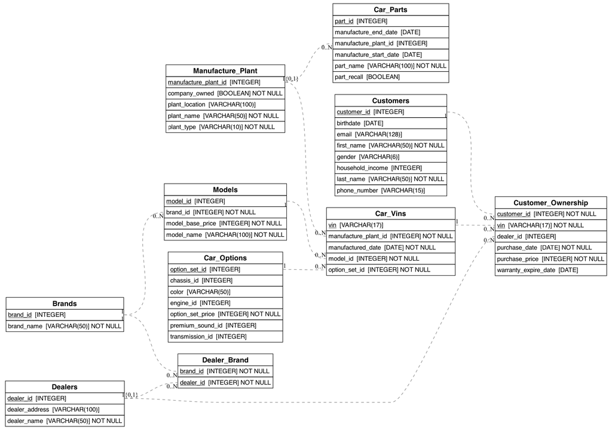

### 1. Update the Submitted by line of this file (1 point)

In the second line of this markdown cell, replace Abraham Lincoln with the name of another famous person and replace the date so that it corresponds to the date on which you are working on this project.

```python
Submitted by Sundar Pichai on December 19th 2025
```

### 2. Import Modules (1 point)

Create a code cell and import functions from the pandas, sqlite3, and matplotlib.pyplot modules.

```python
import pandas as pd
import sqlite3
import matplotlib.pyplot as plt
```

### 3. Display the schema (3 points)

In a new code cell, use Python and SQL to connect to the cars_database.db database, read the schema, convert it to a DataFrame, **dfs**, and display **dfs**.

```python
db_path = r"C:\Users\vmohs\OneDrive\Desktop\cars_database.db"
conn = sqlite3.connect(db_path)

query = """
SELECT name, sql
FROM sqlite_master
WHERE type = 'table';
"""
#Display schema into Dataframe
dfs = pd.read_sql(query, conn)
dfs
```

|  | name | sql |
| --- | --- | --- |
| 0 | Brands | CREATE TABLE Brands (\n brand_id IN... |
| 1 | Manufacture_Plant | CREATE TABLE Manufacture_Plant (\n ... |
| 2 | Models | CREATE TABLE Models (\n model_id IN... |
| 3 | Car_Options | CREATE TABLE Car_Options (\n option... |
| 4 | Car_Parts | CREATE TABLE Car_Parts (\n part_id ... |
| 5 | Car_Vins | CREATE TABLE Car_Vins (\n vin VARCH... |
| 6 | Customers | CREATE TABLE Customers (\n customer... |
| 7 | Dealers | CREATE TABLE Dealers (\n dealer_id ... |
| 8 | Dealer_Brand | CREATE TABLE Dealer_Brand (\n deale... |
| 9 | Customer_Ownership | CREATE TABLE Customer_Ownership (\n ... |

### 4. How many rows are in the Car_Vins table? (2 points)

In a new code cell, use Python to perform a SQL query that displays the number of rows in the Car_Vins table without loading all of the data from the Car_Vins table.

```python
query = """
SELECT COUNT(*) AS total_rows
FROM Car_Vins;
"""
pd.read_sql(query, conn)
```

|  | total_rows |
| --- | --- |
| 0 | 600 |

### 5. Models that cost less than $30,000 (2 points)

In a new code cell use Python to perform a SQL query to read in all observations from the Models table for which the model's base price is less than $30,000 sorted in ascending order of the model's base price. Convert the observations to a DataFrame, **dfm**, and display the resulting DataFrame.

```python
query_price = """
SELECT * FROM Models
WHERE model_base_price < 30000
ORDER BY model_base_price ASC
"""

dfm = pd.read_sql_query(query_price, conn)

dfm
```

|  | model_id | model_name | model_base_price | brand_id |
| --- | --- | --- | --- | --- |
| 0 | 19 | Elantra | 24000 | 7 |
| 1 | 10 | Civic | 25000 | 4 |
| 2 | 17 | K5 | 27000 | 6 |
| 3 | 7 | Camry | 28000 | 3 |
| 4 | 18 | Sportage | 28000 | 6 |
| 5 | 21 | Tucson | 28000 | 7 |
| 6 | 11 | CR-V | 29000 | 4 |

### 6. What is the average option_set_price in the Car_Options table? (2 points)

In a new code cell use Python to run a SQL query that calculates the average option set price from the Car_Options table without reading in all of the data from that table. Display the result.

```python
query = """
SELECT AVG(option_set_price) AS average_option_price
FROM Car_Options;
"""
pd.read_sql(query, conn)
```

|  | average_option_price |
| --- | --- |
| 0 | 3637.5 |

### 7. Joining data with SQL (6 points)

In a new code cell use Python to run a SQL query that joins data from the three tables listed below and converts it into a DataFrame, **df**. Display the first five rows of **df**.

- **Customer_Ownership:** purchase date, purchase price, date that the warranty expired for people that purchased their cars in 2023
- **Dealers:** name and address
- **Customers:** customer's first name, last name, household income

```python
query = """
SELECT
co.purchase_date,
co.purchase_price,
co.warranty_expire_date,
d.dealer_name,
d.dealer_address,
c.first_name,
c.last_name,
c.household_income
FROM Customer_Ownership co
JOIN Dealers d
ON co.dealer_id = d.dealer_id
JOIN Customers c
ON co.customer_id = c.customer_id
WHERE strftime('%Y', co.purchase_date) = '2023';
"""
df = pd.read_sql(query, conn)
df.head()
```

|  | purchase_date | purchase_price | warranty_expire_date | dealer_name | dealer_address | first_name | last_name | household_income |
| --- | --- | --- | --- | --- | --- | --- | --- | --- |
| 0 | 2023-03-06 | 61804 | 2026-03-05 | Northside Cars | 789 Pine Ln, Northville, USA | Sol | Huang | 84029 |
| 1 | 2023-05-15 | 33498 | 2026-05-14 | Elite Auto Group | 101 High St, Metropolis, USA | Min | Guymon | 92942 |
| 2 | 2023-02-19 | 32225 | 2026-02-18 | Northside Cars | 789 Pine Ln, Northville, USA | Malaika | Ibrahim | 50721 |
| 3 | 2023-03-05 | 43961 | 2026-03-04 | Main Street Auto | 123 Main St, Anytown, USA | Jess | Chen | 152434 |
| 4 | 2023-05-20 | 36725 | 2026-05-19 | Main Street Auto | 123 Main St, Anytown, USA | Qiu | Johnson | 131637 |

### 8. Visualize Household Income vs Purchase Price (4 points)

In a new code cell, use Python to create and display a single plot of the data in **df** that shows the distribution of the car's purchase price, as well as the household income. Make sure to include a relevant title and labels on the axes.

[figure not shown]

```python
plt.figure()
plt.scatter(df["household_income"], df["purchase_price"])
plt.xlabel("Household Income")
plt.xlabel("Purchase Price")
plt.title("Household Income vs Car Purchase Price")
plt.show()
```

### 9. Visualize Average Purchase Price for Each Dealer (4 points)

In a new code cell, use Python to create a bar chart with the data in **df** that displays the average purchase price for each dealer. Make sure to include a meaningful title and appropriate labels for the axes.

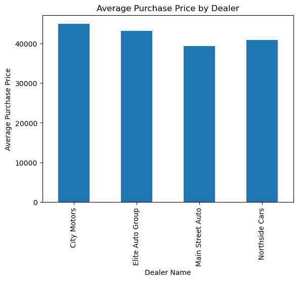

```python
avg_price_by_dealer = df.groupby("dealer_name")["purchase_price"].mean()
plt.figure()
avg_price_by_dealer.plot(kind="bar")
plt.xlabel("Dealer Name")
plt.ylabel("Average Purchase Price")
plt.title("Average Purchase Price by Dealer")
plt.show()
```

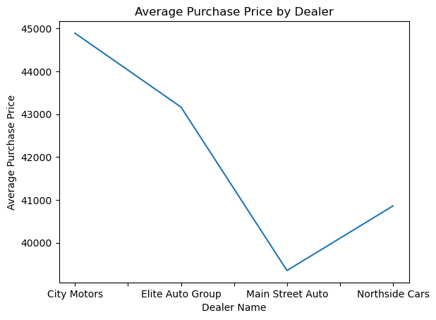

```python
avg_price_by_dealer = df.groupby("dealer_name")["purchase_price"].mean()
plt.figure()
avg_price_by_dealer.plot(kind="line")
plt.xlabel("Dealer Name")
plt.ylabel("Average Purchase Price")
plt.title("Average Purchase Price by Dealer")
plt.show()
```

### 10. Export to HTML and submit

Export the IPYNB file to an HTML format so that it's easy for people to view the results without having to use JupyterLab.

If you're using JupyterLab, as shown in the image below, navigate to the "File" menu, select Save and Export Notebook As, and then select HTML. An HTML version of this file should show up, probably in your Downloads folder. You should then submit this IPYNB file **and** the HTML version of the file.

[figure not shown]

*PDF is more commonly used, but most people will need to install some additional LaTex software for that to work, so we do not require PDF in this course.*